# 20135 - Analysis of CMR data using *mrmr*

Roland Knapp

Analysis of Ranger Station Pond CMR dataset - Tyndall area - “treatment” covariate is included in translocation file to evaluate survival of Bd-exposed and unexposed frogs

## Install mrmr package if current version is not available

```r
remotes::install_github("SNARL1/mrmr")
```

## Install cmdstanr package if current version is not available

```r
install.packages("cmdstanr", repos = c("https://stan-dev.r-universe.dev", getOption("repos")))
cmdstanr::install_cmdstan()
```

## Load packages

```r
if (!require(librarian)){
  install.packages("librarian")
  library(librarian)
}
librarian::shelf(here, cmdstanr, mrmr, bayesplot, posterior, tidyverse)
```

## Create required datasets

```r
captures <- read_csv(here("data", "clean", "20135_capture.csv"))
surveys <- read_csv(here("data", "clean", "20135_survey.csv"))
translocations <- read_csv(here("data", "clean", "20135_reintroduction.csv"))
```

## Specify model formula and check data

```r
data_20135 <- clean_data(captures, surveys, translocations,
                                survival_formula = ~ treatment,
                                survival_fill_value = c(treatment = "unexposed"))
```

## Fit model

```r
# Used default of 1000 iterations for warmup and 1000 iterations for sampling
# "threads per chain" option and "cpp_options" did not speed up fit_model step
model_20135 <- fit_model(
  data_20135,
  chains = 4,
  parallel_chains = 4,
  threads_per_chain = 4,
  cpp_options = list(stan_threads = TRUE)
)
```

## Save model object

```r
model_20135 %>% write_rds(here("out", "model", "20135_model.rds"), "xz", compression = 9L)
```

## Read model objects back in (as necessary)

```r
model_20135 <- read_rds(here("out", "model", "20135_model.rds"))
```

## Evaluate convergence of the MCMC algorithm

- alpha_lamda: Baseline (intercept) of the recruitment process. In a Jolly-Seber model, recruitment (entry of new individuals into the population) in each primary period is modeled using a log link or logit link. For instance, if log(λt )=αλ+ϵλ, then alpha_lambda is the overall mean log recruitment rate across time period.
- sigma_lamda: Standard deviation of temporal random effects on recruitment (ε_λ,t). Therefore, sigma_lamda describes variability in recruitment through time.
- beta_phi[1]: Intercept (baseline effect) for survival probability (φ). Survival is typically modeled on the logit scale: logit(ϕi,t)=βϕ,1+βϕ,2⋅Treatmenti+ϵϕ,t. beta_phi[1] is the average (logit-scale) survival for the reference group — typically “unexposed”.
- beta_phi[2]: Treatment effect on survival probability. Continuing from beta_phi[1] above, beta_phi[2] modifies the baseline logit of survival for the treatment group (e.g., Bd-exposed vs. unexposed). Positive versus negative values indicate that the treatment increased or decreased survival, respectively.
- sigma_phi: Standard deviation of temporal random effects on survival (ε_φ,t). Captures variability in survival between time periods.
- beta_detect[1]: Intercept (baseline effect) for detection probability (p). Represents the average log-odds of detecting an individual per secondary period, in the baseline group (e.g., unexposed).

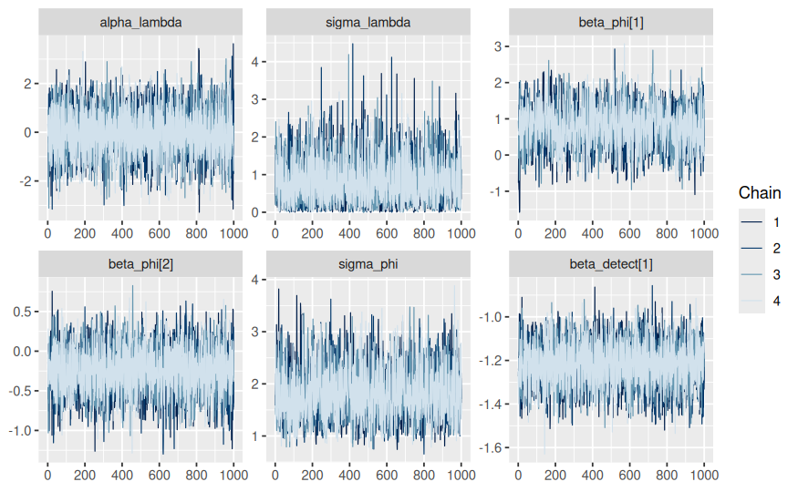

```r
# Traceplots
pars_to_plot <- c("alpha_lambda",
                  "sigma_lambda",
                  "beta_phi",
                  "sigma_phi",
                  "beta_detect")

mcmc_trace(model_20135$m_fit$draws(pars_to_plot))
```

```r
# Summary statistics, include Rhat (any Rhat > 1.01?)
model_20135$m_fit$summary(pars_to_plot)
```

| variable | mean | median | sd | mad | q5 | q95 | rhat | ess_bulk | ess_tail |
| --- | --- | --- | --- | --- | --- | --- | --- | --- | --- |
| alpha_lambda | -0.01576145 | -0.02545418 | 0.98904945 | 0.99044656 | -1.6609591 | 1.6085969 | 1.001097 | 6160.682 | 3052.180 |
| sigma_lambda | 0.79113554 | 0.66287779 | 0.61461426 | 0.59589354 | 0.0545888 | 1.9692141 | 1.000592 | 2828.445 | 1521.322 |
| beta_phi[1] | 0.78313740 | 0.80222697 | 0.56148498 | 0.54586275 | -0.1729173 | 1.6994918 | 1.000287 | 1346.263 | 2129.238 |
| beta_phi[2] | -0.24483566 | -0.24301648 | 0.29691922 | 0.29443837 | -0.7350947 | 0.2310087 | 1.000938 | 4045.413 | 2713.969 |
| sigma_phi | 1.82794433 | 1.78394220 | 0.47579750 | 0.46172434 | 1.1115119 | 2.6914894 | 1.000553 | 2745.931 | 2848.681 |
| beta_detect[1] | -1.21547053 | -1.21311505 | 0.09967058 | 0.09807102 | -1.3855783 | -1.0551377 | 1.000827 | 4858.776 | 3456.334 |

## Built-in visualizations

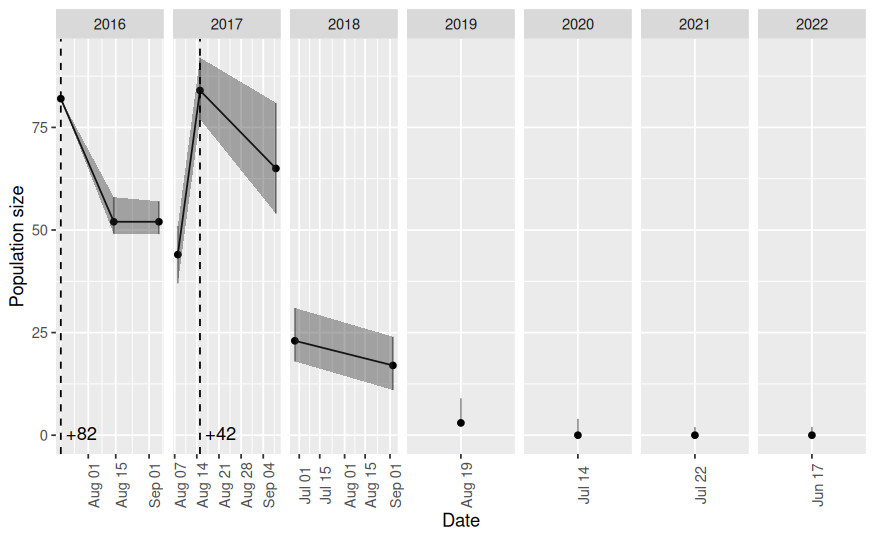

```r
plot_model(model_20135, what = "abundance")
```

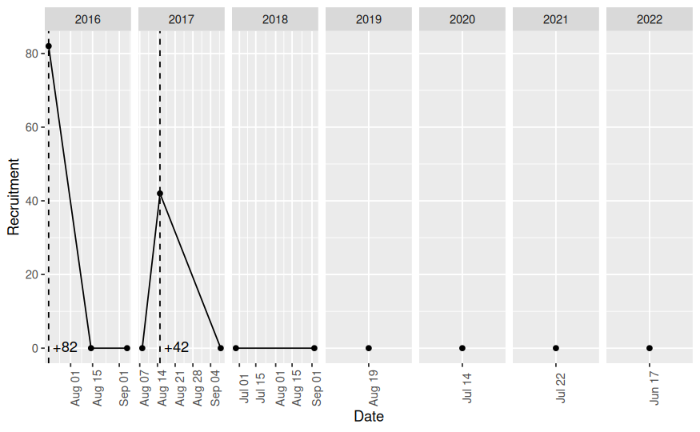

```r
plot_model(model_20135, what = "recruitment")
```

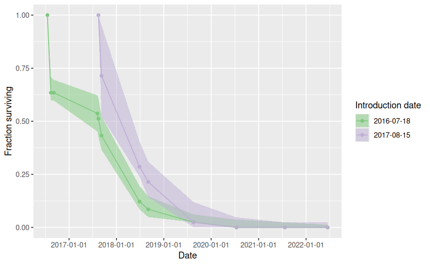

```r
plot_model(model_20135, what = "survival")
```

## Compare posterior estimates for survival: Bd-exposed vs. unexposed individudals

```r
cat("Posterior probability that treatment increased survival:", treatment_prob, "\n")
```

```
Posterior probability that treatment increased survival: 0.206
```

- Posterior probability that treatment increased survival: 0.206. Therefore, there is a 21% posterior probability that the treatment increased survival. Weak evidence at best.

## Plot the posterior distribution of the treatment effect

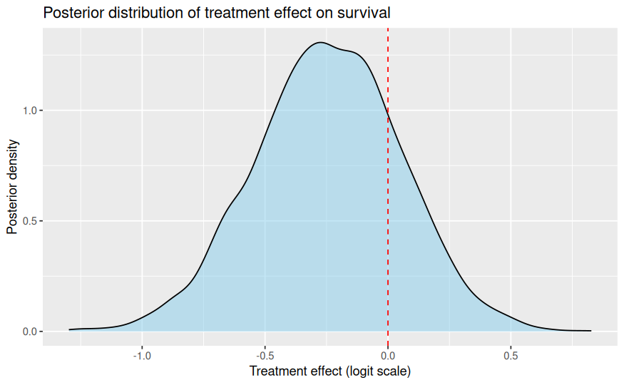

## Custom plots of cohort survival by treatment group

- Plot cohort survival by treatment group, with 95% credible intervals and lines/points on the posterior median.

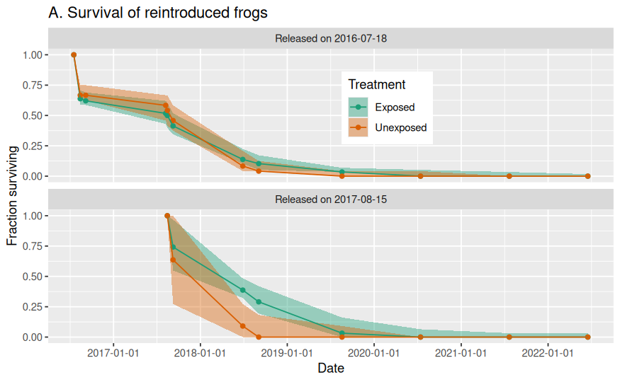

## Arrange survival, abundance, and recruitment plots

```r
# survival plot
p1 <- p1 +
#  guides(fill = guide_legend(nrow = 1)) +
  theme(legend.position = "right")

# abundance plot
p2 <- plot_model(model_20135, what = "abundance")
p2 <- p2 + ggtitle("B. Population size") +
    ylab("Number of adults")

# recruitment plot
p3 <- plot_model(model_20135, what = "recruitment")
p3 <- p3 + ggtitle("C. Recruitment") +
    ylab("Number of adults")

library(patchwork)

p1 / p2 / p3 +
  plot_layout(heights = c(3, 1, 1))

ggsave(here("out", "plots", "20135_mrmr_plots_treatment.png"), width = 6.5, height = 7.2)
```

## Quick model check

- If the treatment increased survival, then in 2018 and 2019, we should have seen a greater proportion of treated than untreated frogs from the initial translocation.

```r
cohort_transloc <- translocations %>%
  filter(release_date == as.Date("2016-07-18"))

count(cohort_transloc, treatment) %>%
  mutate(frac = n / sum(n))

captures %>%
  inner_join(translocations, by = "pit_tag_id") %>%
  select(survey_date, pit_tag_id, treatment) %>%
  filter(survey_date > as.Date("2018-01-01"),
         pit_tag_id %in% cohort_transloc$pit_tag_id) %>%
  group_by(survey_date) %>%
  count(treatment) %>%
  mutate(frac = n / sum(n))
```

[output not shown]